# Pandemic-Era Theft in San Francisco: A Decade in Perspective

In this short project, we focus specifically on **theft-related crimes**, examining how their frequency and distribution changed across time, neighborhoods, and even the time of day. By comparing trends **pre- and post-COVID**, we aim to reveal shifts in behavior and identify areas or time periods with notable changes.

The following visualizations break down the data in three ways: through a time-series view, spatial distribution on maps, and day/night crime patterns, concluding with an interactive visualization for deeper exploration.

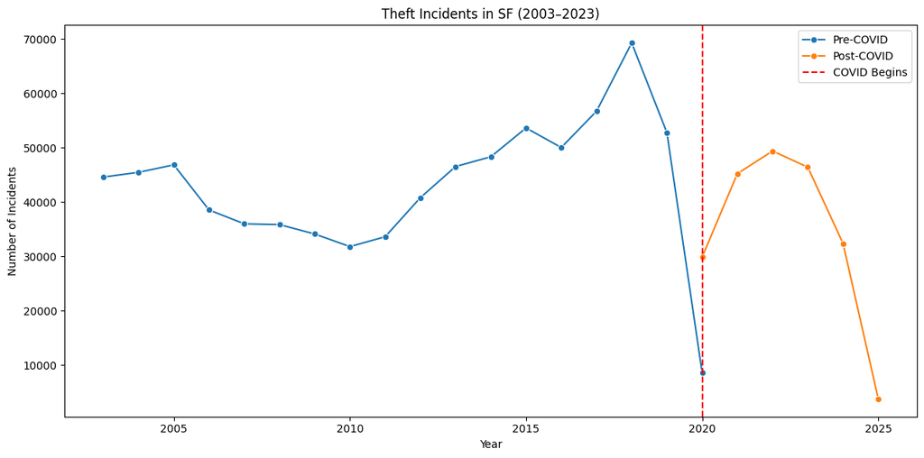

Mapping Theft: Post-COVID Raw Location Distribution

The heatmap below visualizes the geographic distribution of theft incidents in San Francisco after the onset of the COVID-19 pandemic. Each area is color-coded by incident density, with warmer colors indicating higher concentrations of reported thefts.

We can observe that theft activity remains heavily concentrated in established urban hotspots such as Downtown, Mission, and Tenderloin. These areas have historically reported high theft rates, and they continue to do so in the post-pandemic period.

However, compared to pre-COVID trends (not shown here), there appears to be a slight dispersion of incidents into more residential and peripheral neighborhoods. The traditional urban core still dominates, but emerging pockets of activity hint at evolving patterns.

This geographic shift may reflect broader behavioral changes caused by the pandemic—remote work, reduced tourism, and fewer retail and nightlife activities in central areas may have redistributed routine movement patterns, thereby influencing where thefts occur.

Understanding these spatial shifts is critical for tailoring law enforcement resources, urban planning, and community safety initiatives in the post-pandemic city.

```
Post-COVID Theft Heatmap
```

[interactive chart not shown]

### When Does Theft Happen? Day vs Night Trends

Conclusion: A Changing Cityscape

[output not shown]

These three visualizations—across time, space, and daily rhythm—together offer a multifaceted perspective on how theft patterns have shifted. While the pandemic clearly disrupted traditional crime dynamics, it's unclear whether these changes are temporary adaptations or the beginning of a long-term transformation in urban safety.

To truly understand these shifts, continued monitoring of post-pandemic data is necessary—alongside consideration of economic, social, and policy factors that influence crime.